# Graphics with ggplot2

Bea

11/21/2017

# Learning ggplot2

Load Tidyverse

```r
library(tidyverse) ## do this every time you restart R and need it
```

We’re learning ggplot2 It’s going to be amazing.

```r
ohi_data <- read_csv("https://raw.githubusercontent.com/OHI-Science/data-science-training/master/data/OHI_global_data.csv")
```

We start!!

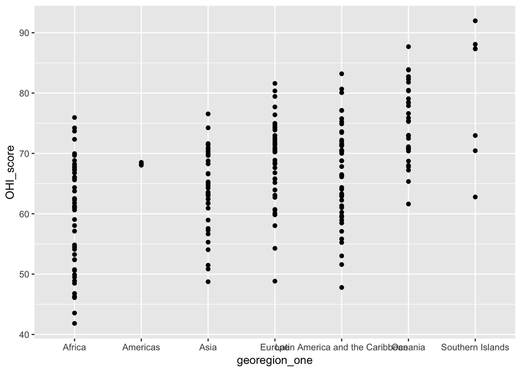

```r
ggplot(ohi_data, aes(x=georegion_one, y=OHI_score)) +
  geom_point()
```

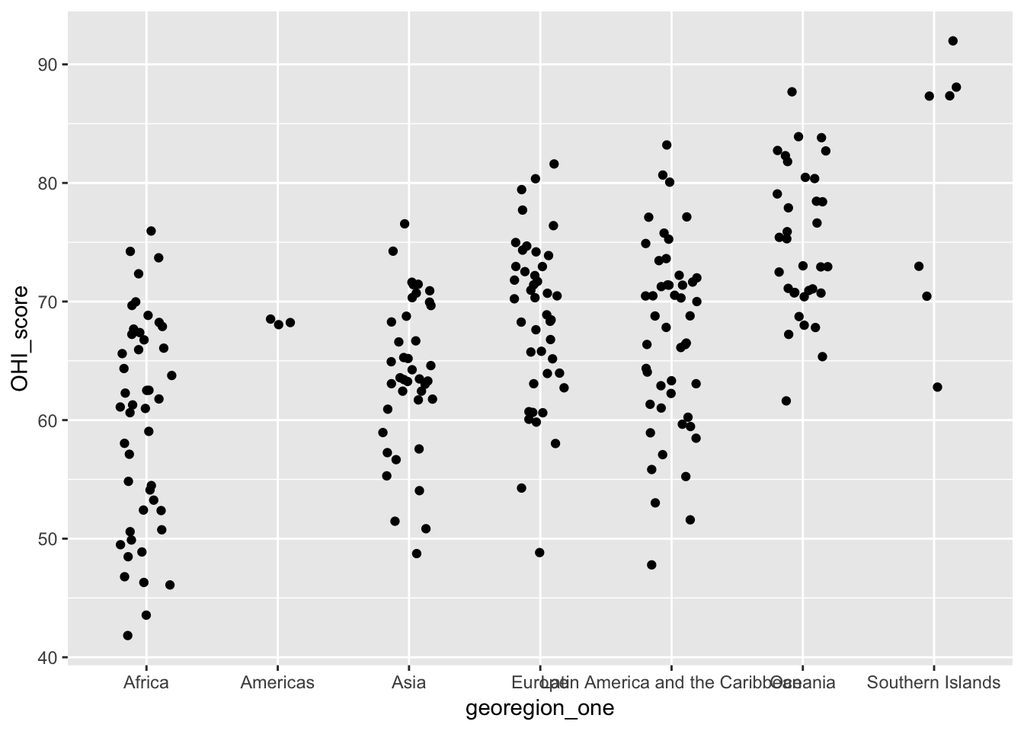

```r
ggplot(ohi_data, aes(x=georegion_one, y=OHI_score)) +
  geom_jitter(width=0.2)
```

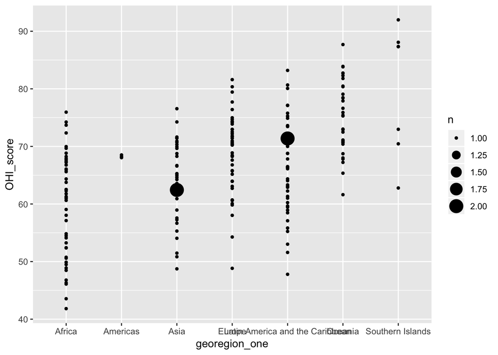

```r
ggplot(ohi_data, aes(x=georegion_one, y=OHI_score)) +
  geom_count()
```

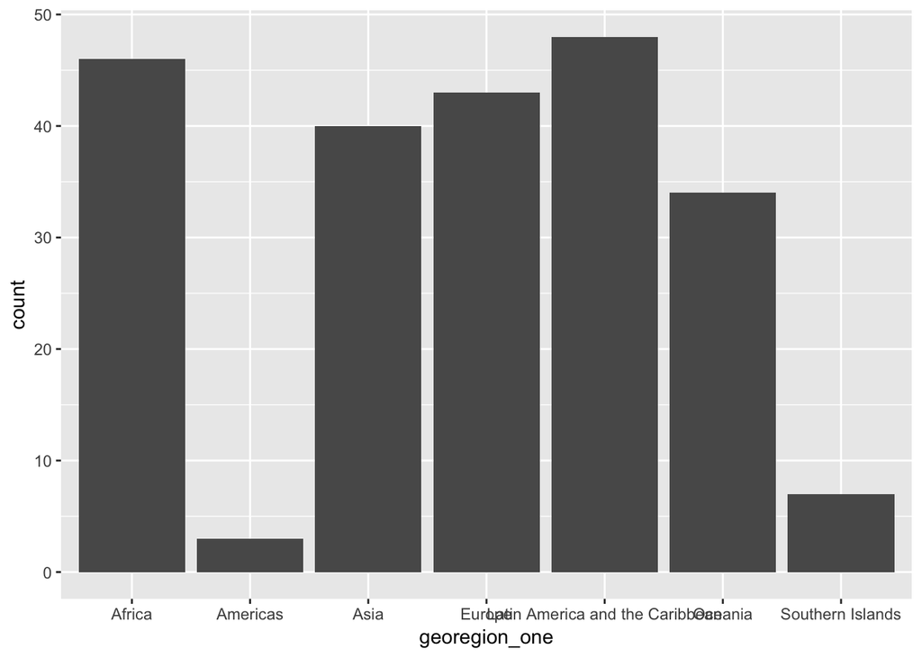

```r
ggplot(ohi_data, aes(x=georegion_one)) +
  geom_bar()
```

Histogram

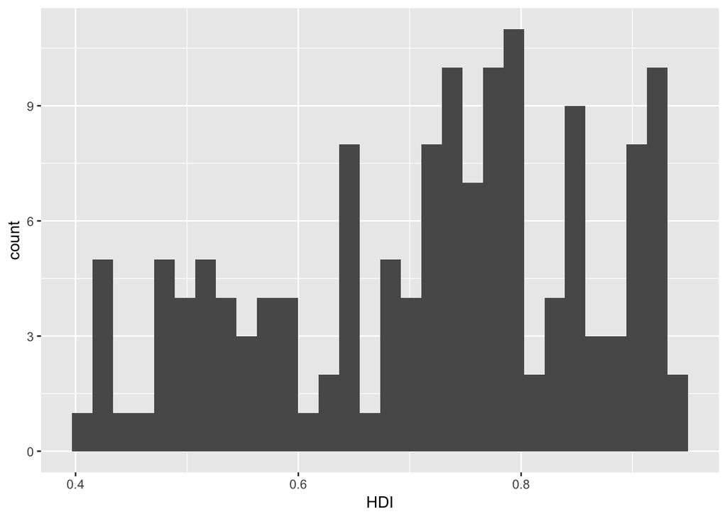

```r
ggplot(ohi_data, aes(x=HDI)) +
  geom_histogram()
```

Multiple geoms exploration

```r
ohi_summary <- read_csv("https://raw.githubusercontent.com/OHI-Science/data-science-training/master/data/OHI_scores_georegion_summary.csv")
```

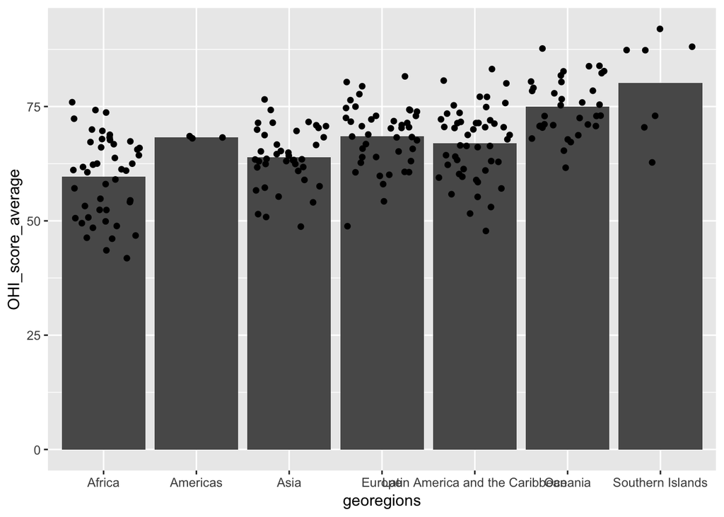

```r
ggplot(ohi_summary, aes(x=georegions, y=OHI_score_average)) +
  geom_bar(stat = "identity") +
  geom_jitter(data= ohi_data, aes(x=georegion_one, y= OHI_score))
```

Are these two approaches the same?

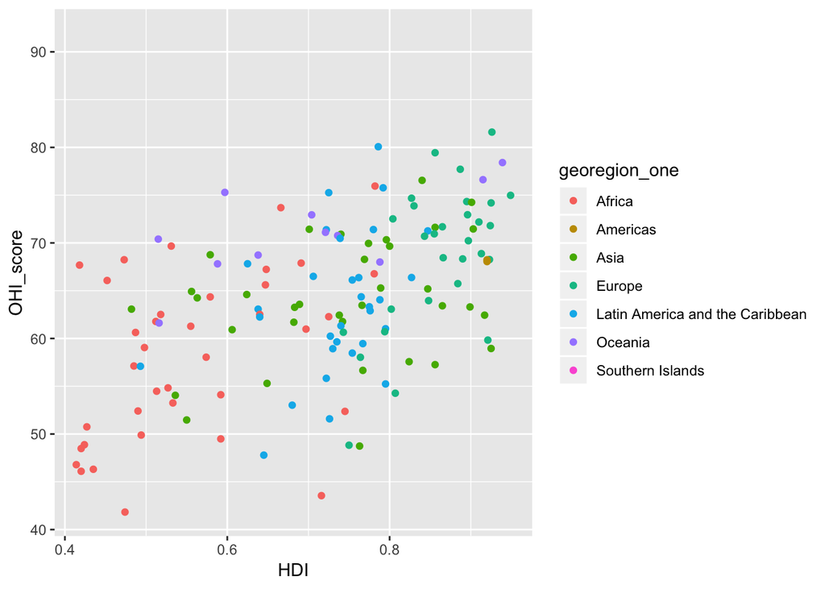

```r
ggplot(data = ohi_data, aes(y=OHI_score, x = HDI, color=georegion_one)) +
  geom_point()
```

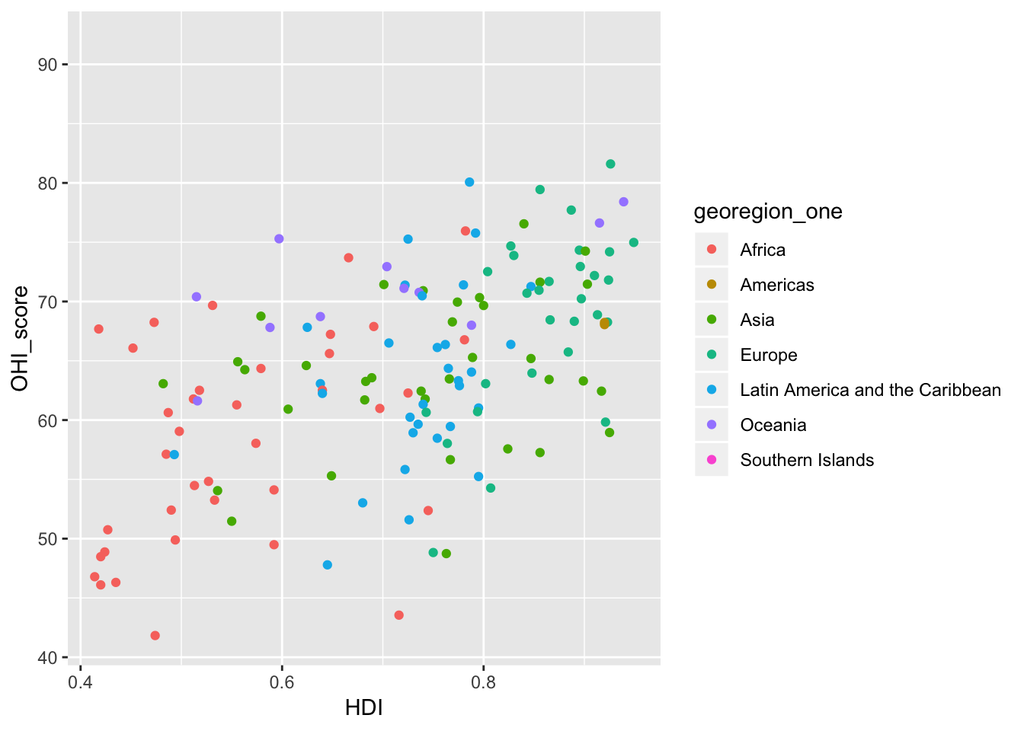

```r
ggplot(data = ohi_data) +
  geom_point(aes(y = OHI_score, x = HDI, color=georegion_one))
```

These two approaches result in the same plot here, but there could be downstream effects as more layers are added.

The arguments within aes() link variables in the dataframe to some aspect of plot appearance. As we have discussed, x and y describe the axes, but other arguments can be added to describe a z variable (e.g. size or color or shape of points). Here are some examples of aes arguments:

color - color of lines/points fill - color within polygons label - name linetype - type of line shape - style of point alpha - transparency (0-1) size - size of shape

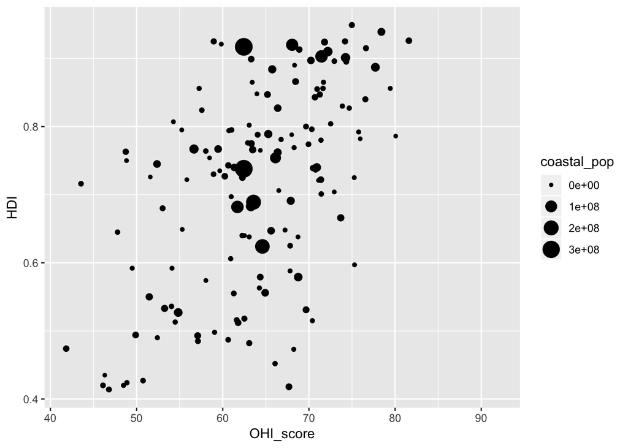

```r
ggplot(data = ohi_data, aes(x = OHI_score, y = HDI, size = coastal_pop)) +
  geom_point()
```

In that code we add a third variable by modifiying the size of the points in the data by coastal_pop variable

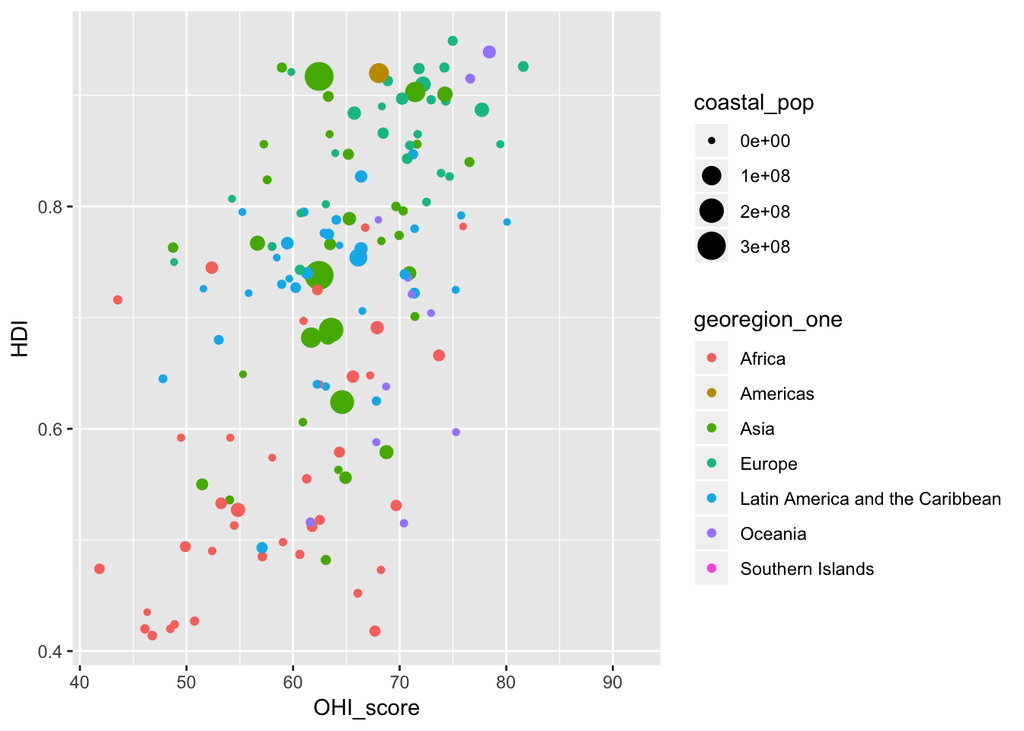

```r
ggplot(data = ohi_data, aes(x = OHI_score, y = HDI, size = coastal_pop, color =georegion_one)) + geom_point()
```

Make our plots way prettier. For that we use themes.

```r
source('https://raw.githubusercontent.com/OHI-Science/ohiprep/master/src/R/scatterTheme.txt')
```

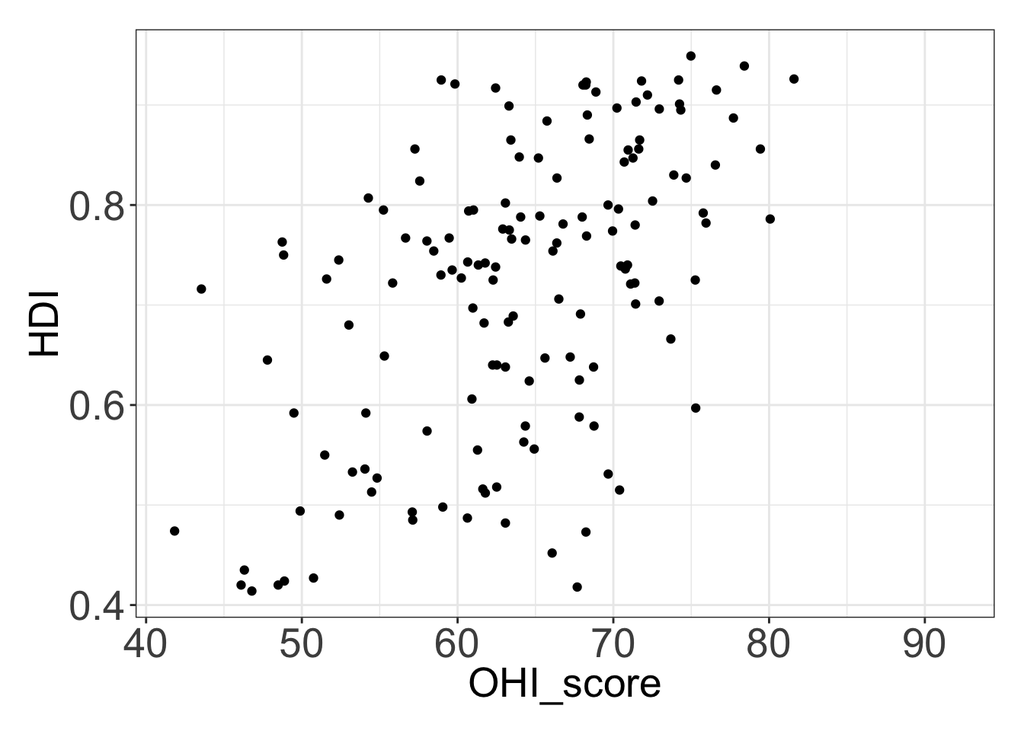

```r
ggplot(ohi_data, aes(x=OHI_score, y= HDI)) +
  geom_point() +
  scatterTheme
```

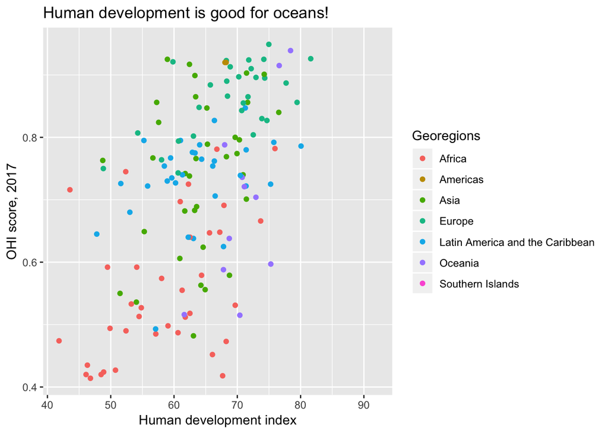

```r
ggplot(ohi_data, aes(x=OHI_score, y= HDI, color=georegion_one)) +
  geom_point() +
  labs(y= "OHI score, 2017", x="Human development index", title= "Human development is good for oceans!", color = "Georegions")
```

Color stuff!!!!! Using RColorBrewer to personalize the color palette

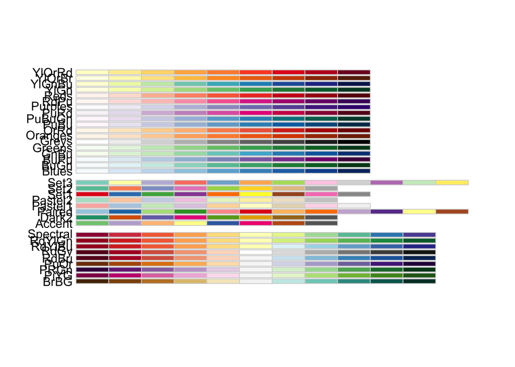

```r
library("RColorBrewer")
library("colorspace")

display.brewer.all()
```

```r
my_palette <- brewer.pal(n=9, "YlOrRd")
```

There are different functions to color the plots depending on the type of variable you have (discrete or continuous).

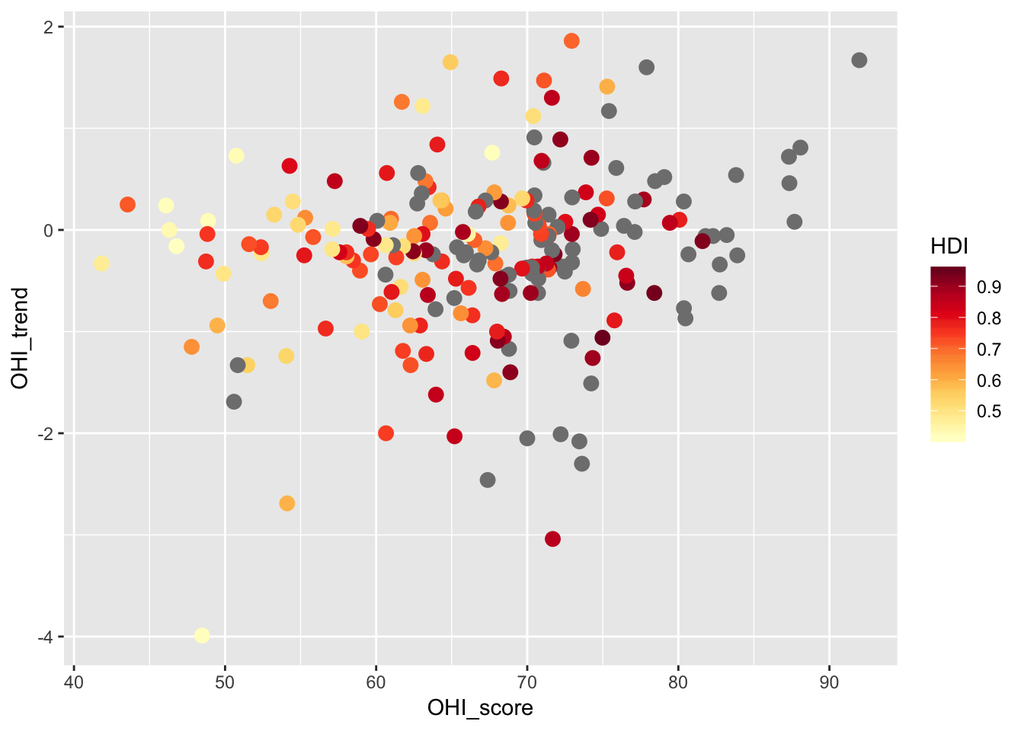

```r
ggplot(ohi_data, aes(x=OHI_score, y=OHI_trend, color=HDI)) +
  geom_point( size = 3) +
  scale_color_gradientn(colors=my_palette)
```

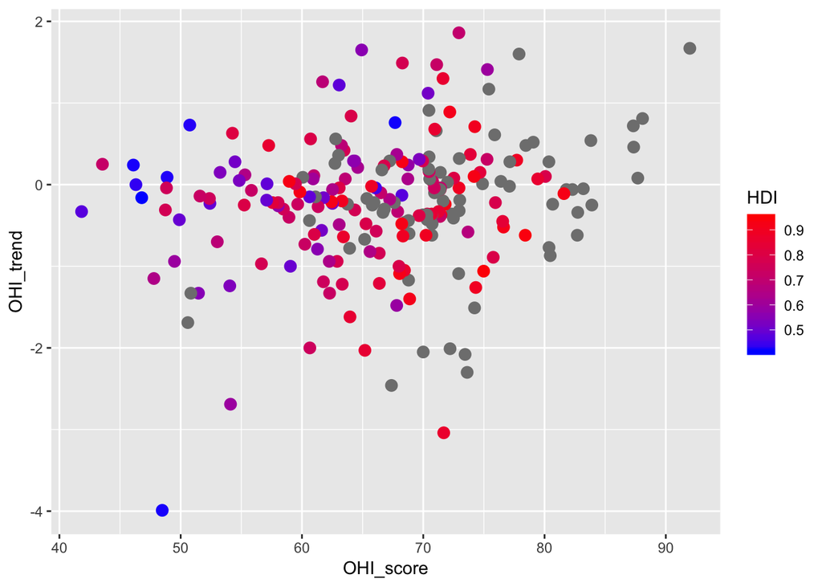

```r
#Assign the color using a vector with discrete colors

ggplot(ohi_data, aes(x=OHI_score, y=OHI_trend, color=HDI)) +
  geom_point( size = 3) +
  scale_color_gradientn(colors=c("blue", "red"))
```

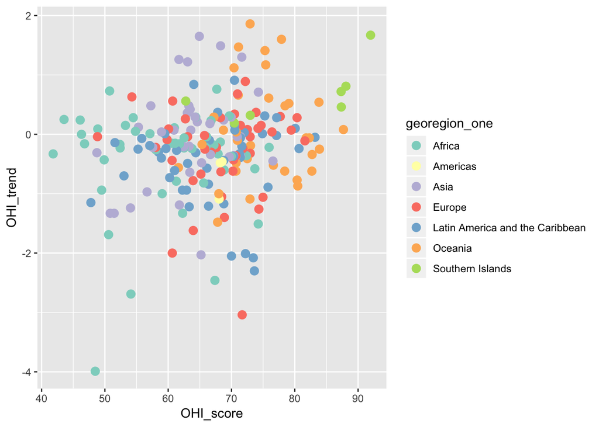

```r
my_palette<-brewer.pal(n=12, "Set3")
ggplot(ohi_data, aes(x=OHI_score, y=OHI_trend, color=georegion_one)) +
  geom_point( size = 3) +
  scale_color_manual(values = my_palette)
```